# Lab-4

Author

YangXu

1. Read in the data

```r
library(R.utils)
library(data.table)
library(leaflet)
library(tidyverse)
if (!file.exists("met_all.gz"))
  download.file(
    url = "https://raw.githubusercontent.com/USCbiostats/data-science-data/master/02_met/met_all.gz",
    destfile = "met_all.gz",
    method   = "libcurl",
    timeout  = 60
    )
met <- data.table::fread("met_all.gz")
```

2. Prepare the data

```r
dim(met)
```

```
[1] 2377343      30
```

```r
# Remove temp less than -17C
met <- met[met$temp > -17]

# check if any missing data coded as 9999,999,etc
summary(met)
```

```
     USAFID            WBAN            year          month        day
 Min.   :690150   Min.   :  116   Min.   :2019   Min.   :8   Min.   : 1
 1st Qu.:720927   1st Qu.: 3705   1st Qu.:2019   1st Qu.:8   1st Qu.: 8
 Median :722720   Median :13841   Median :2019   Median :8   Median :16
 Mean   :723095   Mean   :29496   Mean   :2019   Mean   :8   Mean   :16
 3rd Qu.:725090   3rd Qu.:54768   3rd Qu.:2019   3rd Qu.:8   3rd Qu.:24
 Max.   :726813   Max.   :94998   Max.   :2019   Max.   :8   Max.   :31

      hour            min             lat             lon
 Min.   : 0.00   Min.   : 0.00   Min.   :24.55   Min.   :-124.29
 1st Qu.: 6.00   1st Qu.:20.00   1st Qu.:33.98   1st Qu.: -98.02
 Median :11.00   Median :48.00   Median :38.37   Median : -91.74
 Mean   :11.46   Mean   :39.23   Mean   :37.97   Mean   : -92.14
 3rd Qu.:17.00   3rd Qu.:55.00   3rd Qu.:41.96   3rd Qu.: -82.99
 Max.   :23.00   Max.   :59.00   Max.   :48.94   Max.   : -68.31

      elev           wind.dir      wind.dir.qc        wind.type.code
 Min.   : -13.0   Min.   :  3      Length:2317204     Length:2317204
 1st Qu.: 101.0   1st Qu.:120      Class :character   Class :character
 Median : 252.0   Median :180      Mode  :character   Mode  :character
 Mean   : 415.1   Mean   :185
 3rd Qu.: 400.0   3rd Qu.:260
 Max.   :9999.0   Max.   :360
                  NA's   :732170
    wind.sp       wind.sp.qc          ceiling.ht    ceiling.ht.qc
 Min.   : 0.00   Length:2317204     Min.   :    0   Min.   :1.000
 1st Qu.: 0.00   Class :character   1st Qu.: 3048   1st Qu.:5.000
 Median : 2.10   Mode  :character   Median :22000   Median :5.000
 Mean   : 2.46                      Mean   :16171   Mean   :4.945
 3rd Qu.: 3.60                      3rd Qu.:22000   3rd Qu.:5.000
 Max.   :36.00                      Max.   :22000   Max.   :9.000
 NA's   :31743                      NA's   :73437
 ceiling.ht.method    sky.cond            vis.dist      vis.dist.qc
 Length:2317204     Length:2317204     Min.   :     0   Length:2317204
 Class :character   Class :character   1st Qu.: 16093   Class :character
 Mode  :character   Mode  :character   Median : 16093   Mode  :character
                                       Mean   : 14924
                                       3rd Qu.: 16093
                                       Max.   :160000
                                       NA's   :33666
```

[output cut: 9 more lines]

```
 Min.   :-37.20   Length:2317204     Min.   : 960.5    Min.   :1.000
 1st Qu.: 13.80   Class :character   1st Qu.:1011.8    1st Qu.:5.000
 Median : 18.10   Mode  :character   Median :1014.1    Median :9.000
 Mean   : 17.02                      Mean   :1014.2    Mean   :7.696
 3rd Qu.: 21.70                      3rd Qu.:1016.4    3rd Qu.:9.000
 Max.   : 36.00                      Max.   :1059.9    Max.   :9.000
 NA's   :6287                        NA's   :1606783
       rh
 Min.   :  0.833
 1st Qu.: 55.790
 Median : 76.554
 Mean   : 71.641
 3rd Qu.: 90.629
 Max.   :100.000
 NA's   :6287
```

```r
# Replace missing data in elev with NA
met <- met[elev == 9999, elev:=NA]

# Generate a date variable
met[, week := week(as.Date(paste(year, month, day, sep = "-")))]
met <- met[week == min(week, na.rm = TRUE)]
# Compute the mean
met_avg <- met[,.(
  temp     = mean(temp,na.rm = TRUE),
  rh       = mean(rh,na.rm = TRUE),
  wind.sp  = mean(wind.sp,na.rm=TRUE),
  vis.dist = mean(vis.dist,na.rm=TRUE),
  dew.point = mean(dew.point, na.rm=TRUE),
  lat      = mean(lat),
  lon      = mean(lon),
  elev     = mean(elev,na.rm=TRUE)
),by = c("USAFID","day")]

# Create region variables
met_avg$region <- ifelse(met_avg$lon > -98 & met_avg$lat >39.71, "NE",
                  ifelse(met_avg$lon > -98 & met_avg$lat < 39.71, "SE",
                  ifelse(met_avg$lon < -98 & met_avg$lat >39.71, "NW",
                         "SW")))
# Create a categorical variable for elevation
met_avg[, elev_cat := fifelse(elev > 252, "high", "low")]
```

3. Examine the wind speed and dew point by region

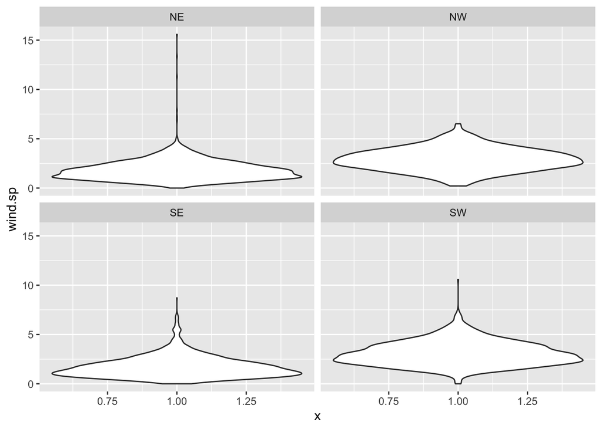

```r
# Use geom_violin
met_avg[!is.na(region)] %>%
ggplot()+
  geom_violin(mapping = aes(y=wind.sp, x=1)) +
  facet_wrap(~region, nrow=2)
```

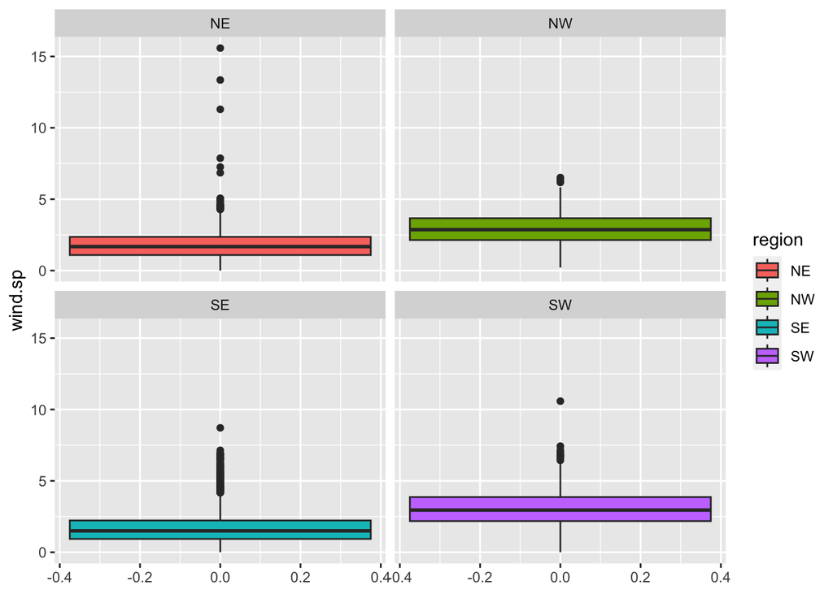

```r
# Use geom_boxplot
met_avg[!is.na(region)] %>%
ggplot()+
  geom_boxplot(mapping = aes(y=wind.sp, fill=region)) +
  facet_wrap(~region, nrow=2)
```

A violin plot is a mirrored density plot displayed in the same way as a boxplot. From the violin plot, we observe that NE and SE have lower average wind speed than SW and NW. The distribution of wind speed in SE and NE are less dispersed than SW and NW.

4. Examine the association between dew point and wind speed by region

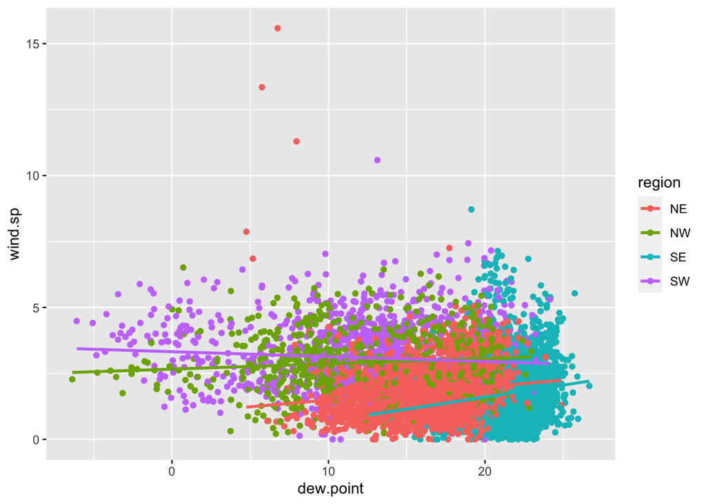

```r
met_avg[!is.na(region)] %>%
  ggplot(mapping = aes(x=dew.point, y=wind.sp, color=region))+
  geom_jitter() +
  stat_smooth(method=lm, se = FALSE)
```

From the plot, we observe that in NW, NE and SE, with dew point increasing, the average wind speed gets higher. But in SW, with dew point increasing, the average wind speed gets lower.

5. Create barplots of the weather stations by elevation category colored by region

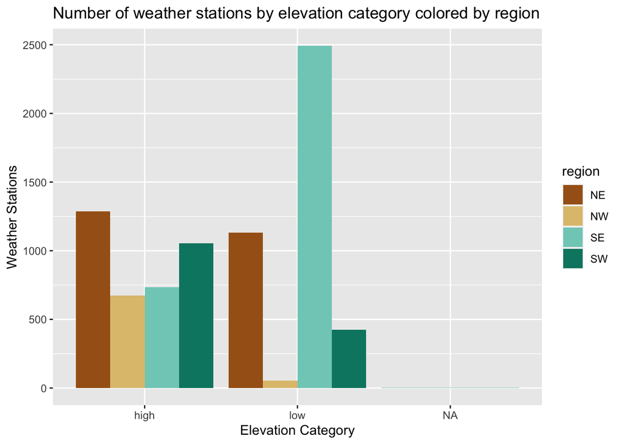

```r
met_avg[!is.na(region)] %>%
  ggplot()+
  geom_bar(mapping=aes(x=elev_cat,fill=region), position = "dodge")+
  scale_fill_brewer(palette = "BrBG")+
  labs(title="Number of weather stations by elevation category colored by region")+
  labs(x="Elevation Category", y= "Weather Stations")
```

From the plot, we observe that in high elevation area, NE has the most weather stations. In low elevation area, SE has the most weather stations.

6. Examine mean dew point and wind speed by region with standard deviation error bars

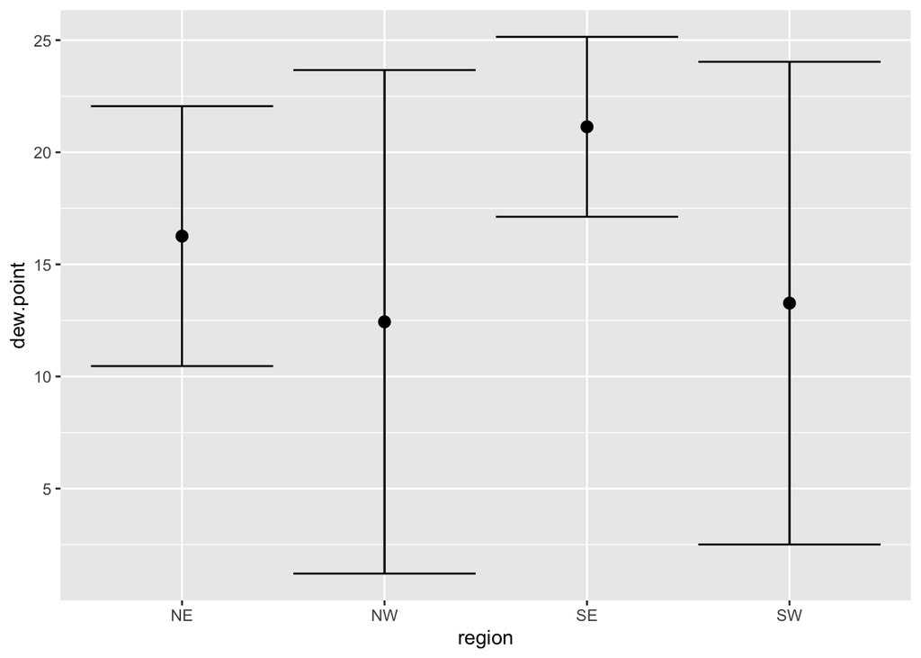

```r
met_avg[!is.na(region)] %>%
  ggplot(mapping=aes(x=region, y=dew.point)) +
  stat_summary(fun.data="mean_sdl", geom="errorbar") +
  stat_summary(fun.data="mean_sdl")
```

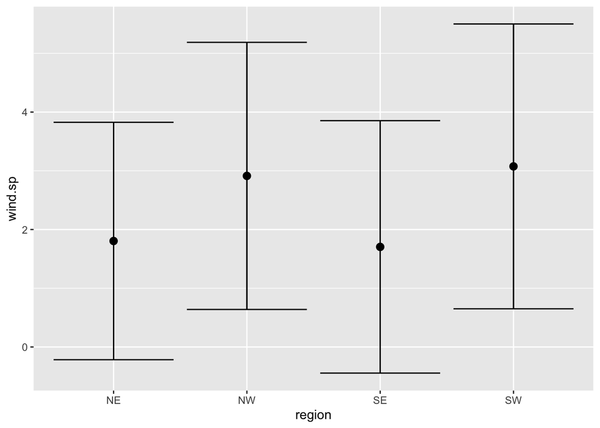

```r
met_avg[!is.na(region)] %>%
  ggplot(mapping=aes(x=region, y=wind.sp)) +
  stat_summary(fun.data="mean_sdl", geom="errorbar") +
  stat_summary(fun.data="mean_sdl")
```

SE has the highest mean dew point. SW has the highest mean wind speed.

7. Make a map showing the spatial trend in relative humidity in the US

```r
met_avg2 <- met_avg[!is.na(rh)]
# color plaette
rh.pal <- colorNumeric(c('darkgreen','goldenrod','brown'), domain=met_avg2$rh)
# Top10 places
top10 <- met_avg2[rank(-rh) <= 10]
leaflet(met_avg2) %>%
  addProviderTiles('OpenStreetMap') %>%
  addCircles(lat=~lat, lng=~lon, color=~rh.pal(rh), label=~paste0(round(rh,2), ' rh'), opacity=1,fillOpacity=1, radius=500) %>%
  addMarkers(lat=~lat, lng=~lon, label=~paste0(round(rh,2), ' rh'), data = top10) %>%
  addLegend('bottomleft',pal=rh.pal, values=met_avg2$rh, title="Relative Humidity", opacity=1)
```

[interactive chart not shown]

Mid-west area of the US has the average lowest RH across the country. The closer to the east and west coasts, the higher the RH.

8. Use a ggplot extension

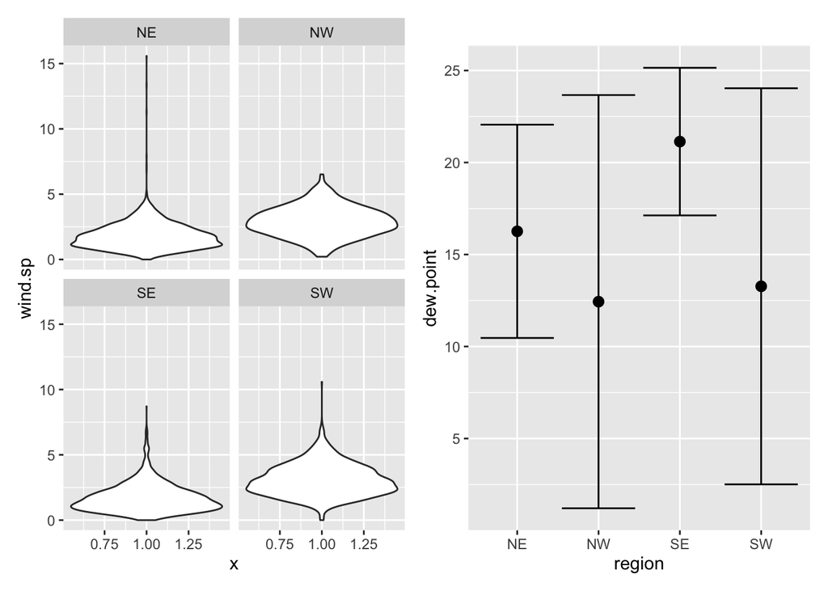

```r
library(patchwork)
p1 <- met_avg[!is.na(region)] %>%
ggplot()+
  geom_violin(mapping = aes(y=wind.sp, x=1)) +
  facet_wrap(~region, nrow=2)

p2 <- met_avg[!is.na(region)] %>%
  ggplot(mapping=aes(x=region, y=dew.point)) +
  stat_summary(fun.data="mean_sdl", geom="errorbar") +
  stat_summary(fun.data="mean_sdl")
p1 + p2
```